# Внешний курс. Блок 1 - Безопасность в сети

Основы информационной безопасности

Панина Жанна Валерьевна

1132246710@rudn.ru

Российский университет дружбы народов

2026-05-16

# Информация

## Докладчик

- Панина Жанна Валерьевна
- студентка НКАбд-02-24
- Российский университет дружбы народов им. П. Лумумбы
- 1132246710@rudn.ru
- https://github.com/zvpanina/study_2025-2026_infosec-intro
- Преподаватель: Кулябов Дмитрий Сергеевич, профессор кафедры теории вероятностей и кибербезопасности

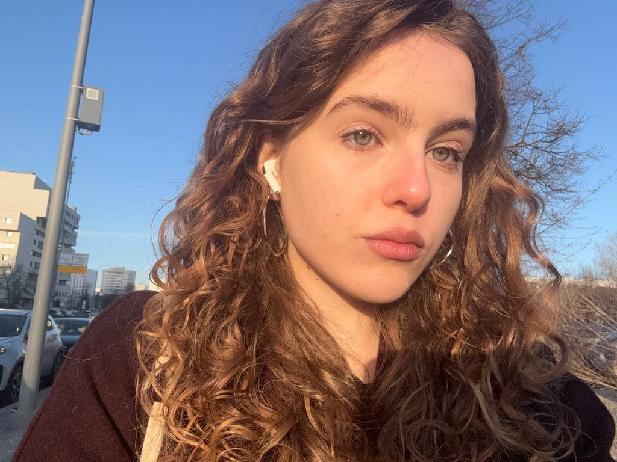

# Вводная часть

## Актуальность

- Рост числа сетевых атак и фишинга
- Использование небезопасных соединений
- Необходимость защиты персональных данных в Интернете

## Объект и предмет исследования

### Объект исследования:

Сетевое взаимодействие в компьютерных системах

### Предмет исследования:

Протоколы передачи данных и механизмы защиты сетевого трафика

## Цели и задачи

Цель - изучение принципов безопасного сетевого взаимодействия

Задачи:

- изучить модель TCP/IP;
- рассмотреть работу HTTP и HTTPS;
- исследовать TLS и cookies;
- изучить принципы работы TOR и Wi-Fi

## Материалы и методы

Материалы:

- курс Stepik;
- сетевые протоколы и технологии;
- тестовые задания

Методы:

- анализ сетевых технологий;
- сравнение протоколов;
- выполнение практических заданий

# Основная часть: Выполнение заданий 1 блока

## Как работает интернет: базовые сетевые протоколы

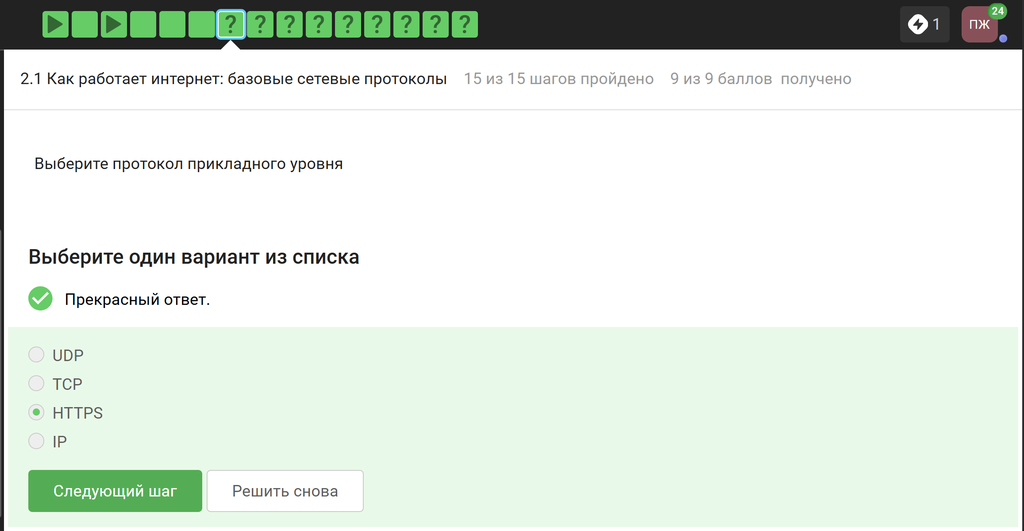

Рисунок 1: Вопрос 1

Протокол TCP - Transmission Control Protocol, он работает на транспортном уровне.

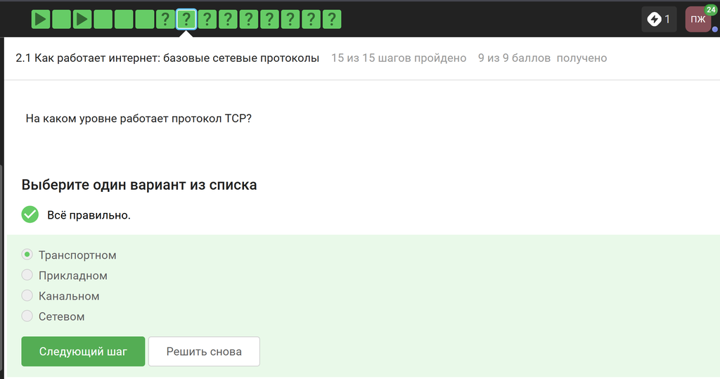

Рисунок 2: Вопрос 2

В адресе типа IPv4 не может быть чисел больше 255, значит, первые два варианта неправильные.

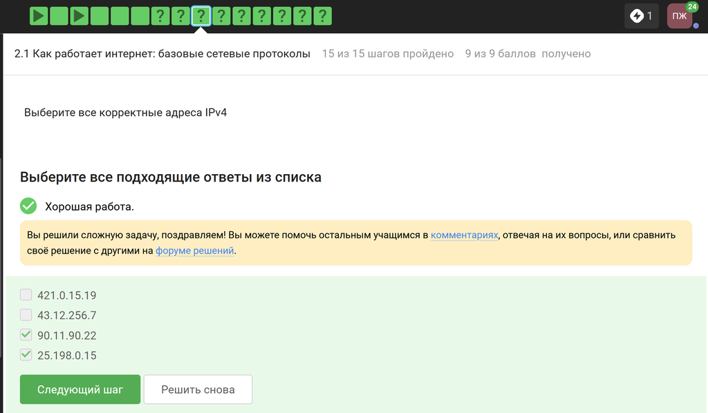

Рисунок 3: Вопрос 3

DNS - Domain Name Server - приложение, предназначенное для ответов на DNS-запросы по соответствующему протоколу. Обязательное условие - сопоставление сервером доменных имён с IP-адресами - разрешение имени и адреса.

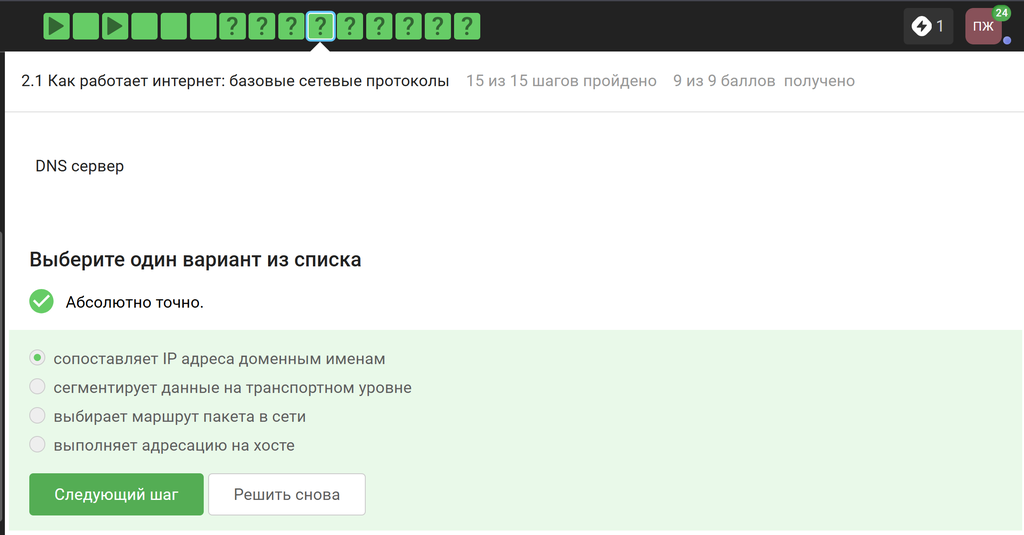

Рисунок 4: Вопрос 4

Распределение протоколов в модели TCP/IP:

- Прикладной уровень: HHTP, RTSP, FTP, DNS
- Транспортный уровень: TCP, UDP, SCTP, DCCP
- Сетевой уровень: IP
- Канальный уровень: Ethernet, IEEE 802.11, WLAN, SLIP, Token Ring, ATM, MPLS.

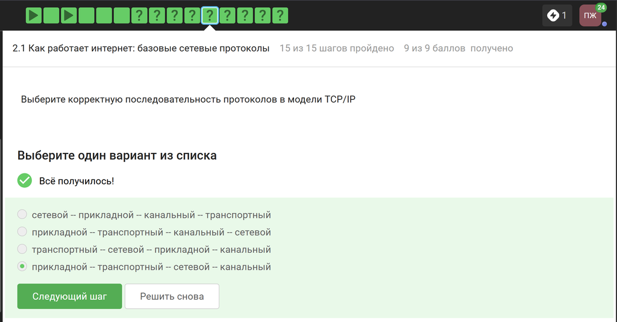

Рисунок 5: Вопрос 5

Протокол http передаёт незашифрованные данные, а протокол https уже будет передавать их в зашифрованном виде.

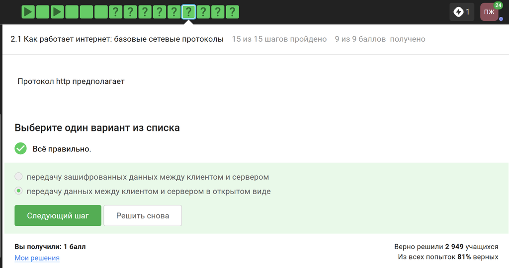

Рисунок 6: Вопрос 6

Протокол https передаёт зашифрованные данные, одна из фаз - передача данных, другая - рукопожатие.

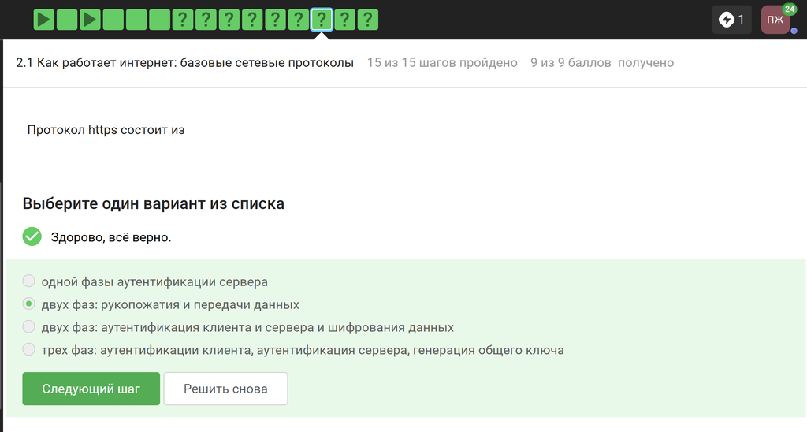

Рисунок 7: Вопрос 7

TLS определяется и клиентом, и сервером, чтобы было возможно подключиться.

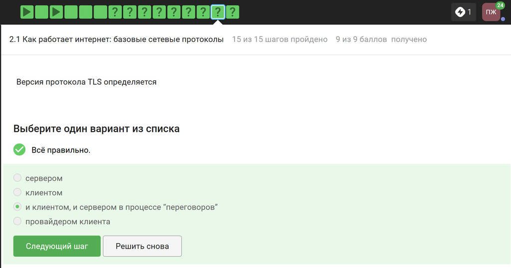

Рисунок 8: Вопрос 8

Не предусмотрено из перечисленных вариантов только шифрование данных.

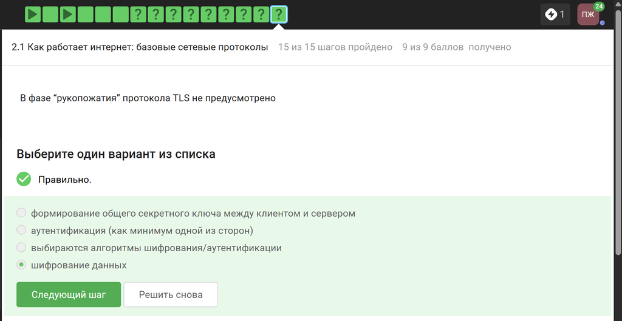

Рисунок 9: Вопрос 9

## Перслнализация сети

Куки точно не хранят пароли и IP-адреса, а ID сессии и идентификатор хранят.

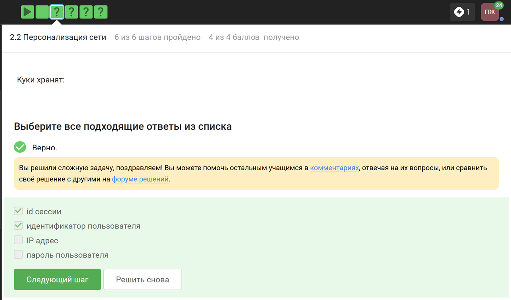

Рисунок 10: Вопрос 10

Естественно куки не делают соединение более надёжным.

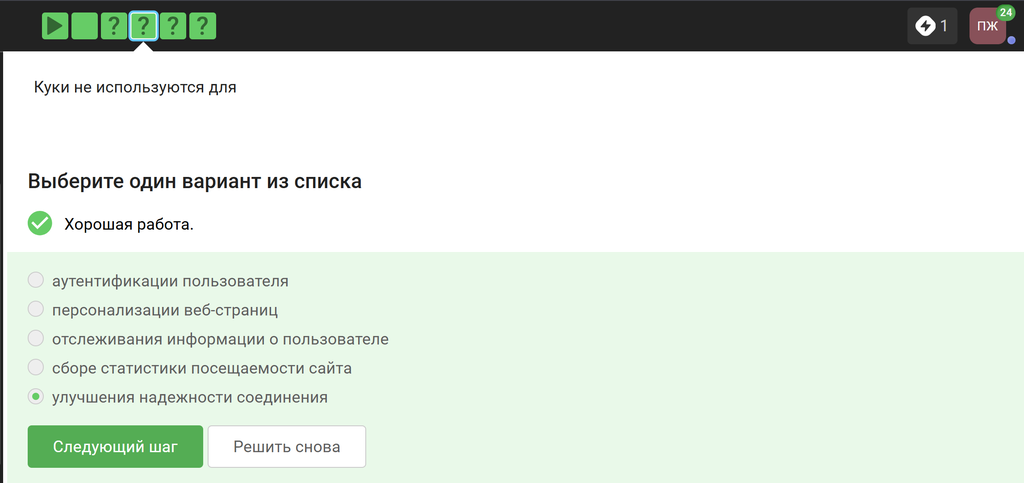

Рисунок 11: Вопрос 11

Ответ представлен на изображении.

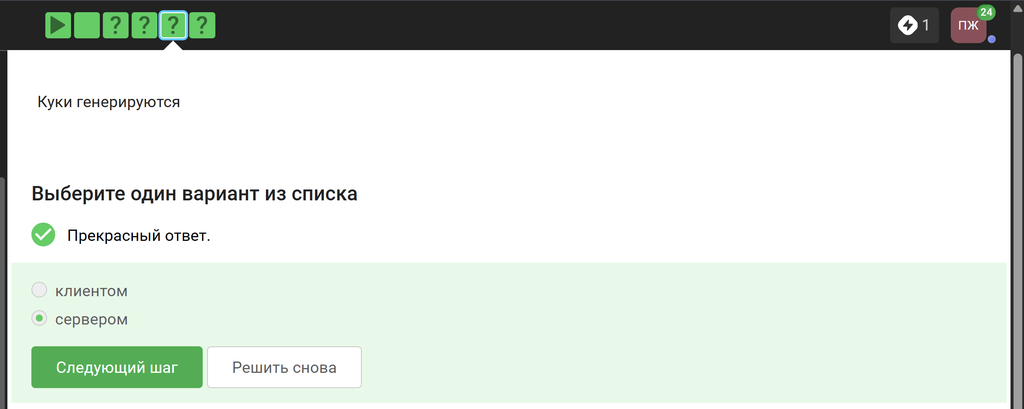

Рисунок 12: Вопрос 12

Сессионные куки хранятся в течение сессии, то есть, пока используется веб-сайт.

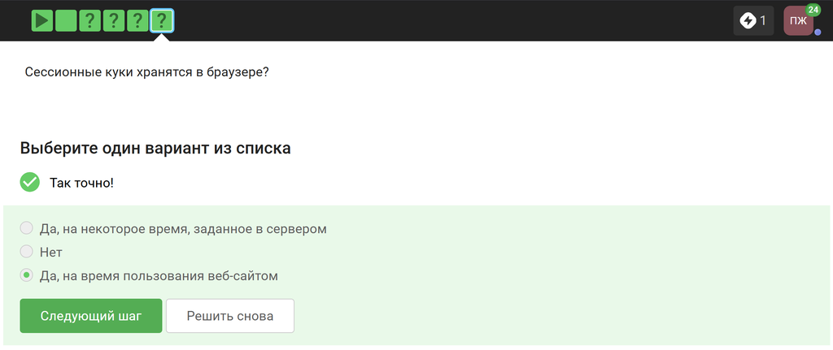

Рисунок 13: Вопрос 13

## Браузер TOR. Анонимизация

Необходимо три узла - входной, промежуточный и выходной.

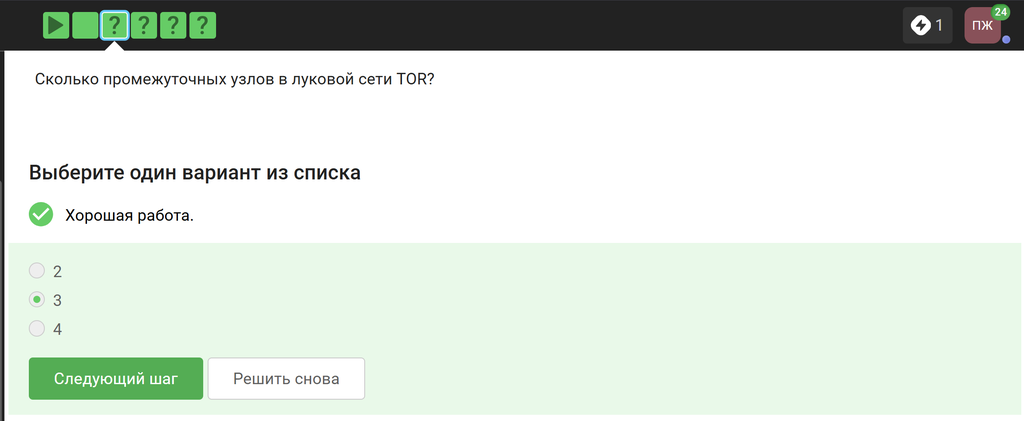

Рисунок 14: Вопрос 14

IP-адрес не должен быть известен охранному и промежуточному узлам.

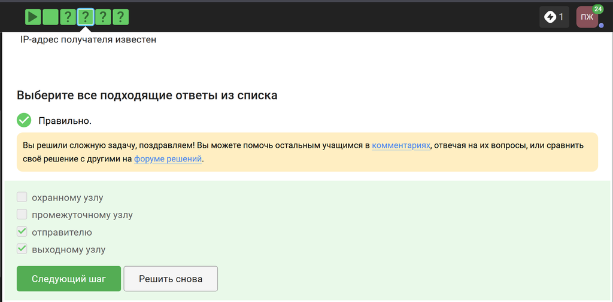

Рисунок 15: Вопрос 15

Отправитель генерирует общий секретный ключ с узлами, через которые идёт передача, то есть, со всеми перечисленными.

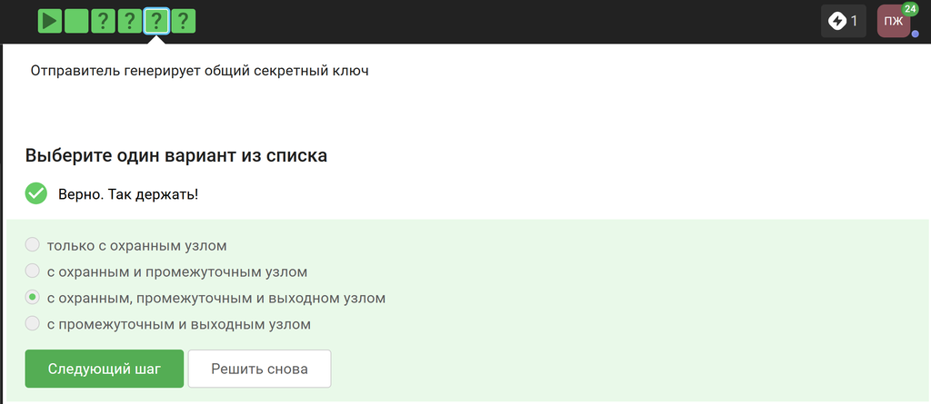

Рисунок 16: Вопрос 16

Для получения пакетов не нужно использовать TOR. TOR - это технология, которая позволяет с некоторым успехом скрыть личность человека в интернете.

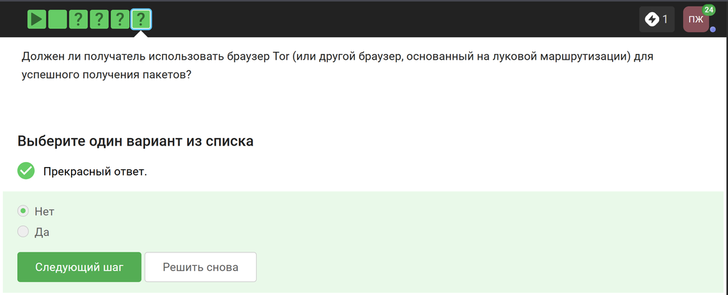

Рисунок 17: Вопрос 17

## Беспроводные сети Wi-Fi

Выбранное определенние наиболее точно.

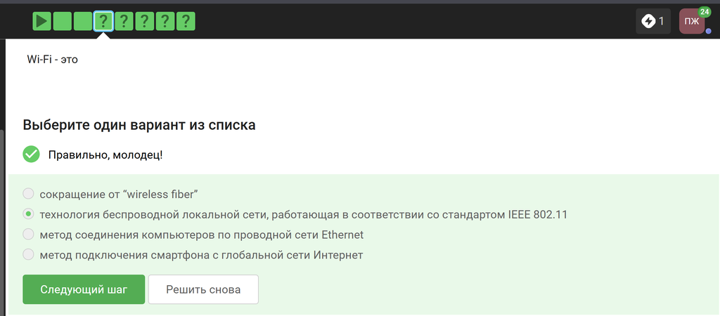

Рисунок 18: Вопрос 18

Для целей работы в Интернете Wi-Fi обычно располагается как канальный уровень (эквивалентный физическому и канальному уровням модели OSI) ниже интернет-уровня интернет-протокола. Это означает, что узлы имеют связанный интернет-адрес, и при подходящем подключении это обеспечивает полный доступ в Интернет.

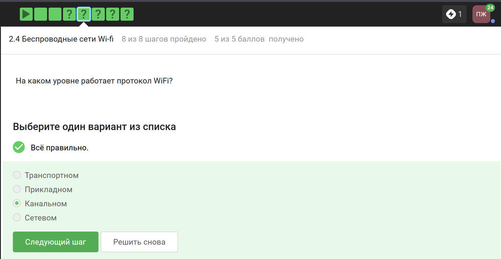

Рисунок 19: Вопрос 19

WEP (Wired Equivalent Privacy) - устаревший и небезопасный метод проверки подлинности. Это первый и не очень удачный метод защиты. Злоумышленники без проблем получают доступ к беспроводным сетям, которые защищены с помощью WEP, он был заменён остальными представленными.

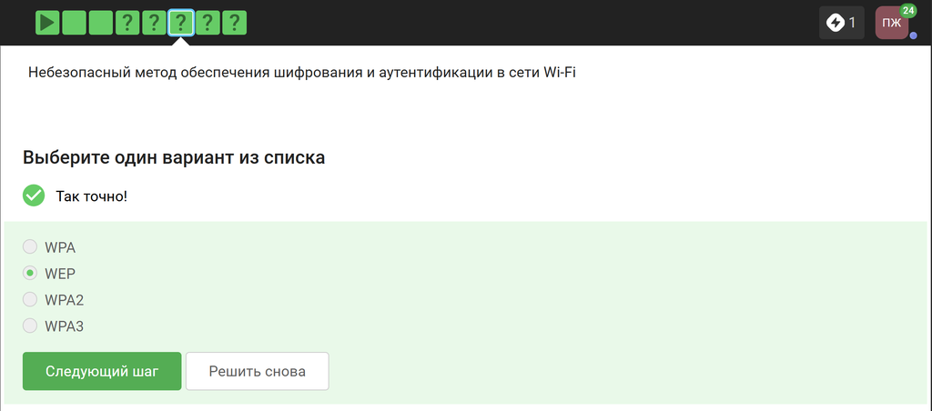

Рисунок 20: Вопрос 20

Нужно аутентифицировать устройства и позже передаются зашифрованные данные.

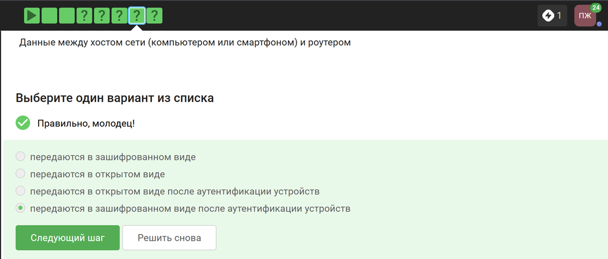

Рисунок 21: Вопрос 21

WPA2 Personal предназначен для личного использования, то есть, для домашней сети, Enterprise - для предприятий.

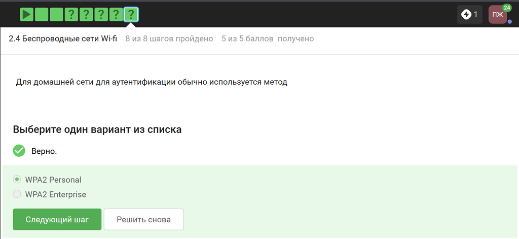

Рисунок 22: Вопрос 22

## Анализ и практическая значимость

- Изучены механизмы защиты сетевого трафика
- Рассмотрены HTTPS, TLS, cookies, TOR и Wi-Fi
- Получены навыки анализа сетевых угроз
- Показано практическое значение защищённых соединений